# Introduction to R - Exercises

Candace Savonen

2020

The goal of these exercises is to help you get comfortable with using R and R notebooks by continuing to play with the dataset we used in the 01-intro_to_base_R notebook and 02-intro_to_ggplot2 notebooks.

## Objectives

- Load tidyverse
- Read in TSV file as a data frame
- Practice subsetting data frame and exploring data structure
- Use R functions to manipulate data
- Save data frame to TSV
- Create a plot
- Save plot to a file

### Set Up

Use this chunk to load the `tidyverse` library.

```r
library(tidyverse)
```

## Read in the gene results file

Use `readr::read_tsv` to read in the file “gene_results_GSE44971.tsv” and assign it the name `stats_df`.

```r
stats_df <- readr::read_tsv(file.path("data", "gene_results_GSE44971.tsv"))
```

Use this chunk to explore what your data frame, `stats_df` looks like.

```r
head(stats_df)
```

| ensembl_id | gene_symbol | contrast | log_fold_change | avg_expression | t_statistic | p_value | adj_p_value |
| --- | --- | --- | --- | --- | --- | --- | --- |
| ENSG00000000003 | TSPAN6 | male_female | -4.0768850 | 8.361818 | -2.5244352 | 0.01451222 | 0.08819912 |
| ENSG00000000419 | DPM1 | male_female | 1.1616735 | 10.500009 | 1.1274096 | 0.26447729 | 0.58270423 |
| ENSG00000001561 | ENPP4 | male_female | 0.8818637 | 5.923962 | 0.7604491 | 0.45024291 | 0.75934004 |
| ENSG00000001629 | ANKIB1 | male_female | -2.9855452 | 12.328982 | -1.8550314 | 0.06896947 | 0.25689791 |
| ENSG00000002549 | LAP3 | male_female | -1.4266361 | 12.001801 | -0.5535544 | 0.58213349 | 0.84898701 |
| ENSG00000002586 | CD99 | male_female | 0.7312213 | 19.084011 | 0.1655914 | 0.86908734 | 0.97197433 |

## Read in the metadata

Use `readr::read_tsv` to read in the file “cleaned_metadata_GSE44971.tsv” and assign it the name `metadata`.

```r
metadata <- readr::read_tsv(file.path("data", "cleaned_metadata_GSE44971.tsv"))
```

Use this chunk to explore what your data frame, `metadata` looks like.

```r
str(metadata)
```

```
Classes ‘spec_tbl_df’, ‘tbl_df’, ‘tbl’ and 'data.frame':    58 obs. of  5 variables:
 $ sample_id     : chr  "GSM1094830" "GSM1094853" "GSM1094846" "GSM1094869" ...
 $ sex           : chr  "male" "male" "female" "male" ...
 $ tissue        : chr  "pilocytic_astrocytoma" "pilocytic_astrocytoma" "pilocytic_astrocytoma" "normal_cerebellum_control" ...
 $ brain_location: chr  "Cerebellum" "Cerebellum" "Cerebellum" "Cerebellum" ...
 $ title         : chr  "PA_17" "PA_68" "PA_64" "CTRL_CBM_13" ...
 - attr(*, "spec")=
  .. cols(
  ..   sample_id = col_character(),
  ..   sex = col_character(),
  ..   tissue = col_character(),
  ..   brain_location = col_character(),
  ..   title = col_character()
  .. )
```

### Subsetting variables

Use subsetting to take a look at the `avg_expression` column.

```r
stats_df$avg_expression
```

```
   [1]   8.361818  10.500009   5.923962  12.328982  12.001801  19.084011   8.453933   5.116563
   [9]   6.345609  25.473133  38.866912   5.613841   7.539868  12.052861  24.832742   7.568481
  [17]   7.765075  12.116466   5.185520   9.674196   8.880052   5.420666   8.545795   5.860617
  [25]  25.752680   6.731484  17.466032   9.638069  10.598742   6.152062  22.682215   9.150479
  [33]   5.126262  17.137658  16.342516  10.083913  16.985986   9.718591   9.103716   5.069792
  [41]  13.123381  19.842813   5.719139   6.099870   8.171732  10.560318  28.484791   7.565464
  [49]   8.466025   6.892540   7.548145  31.617065  17.325848   5.265291   8.989985  18.990736
  [57]   9.652945  19.483830   7.709459 123.274072  13.866606   6.895693   5.701373   8.037877
  [65]  10.107804   5.784972 108.879096  45.722196   6.202930  17.501360   5.622557  13.216234
  [73]  21.520975   5.200199   8.348036  13.462684   6.288637  11.800851   7.242380   8.429338
  [81]  74.855947   7.651266  14.237903   7.152891  19.720394   8.032124   6.219822   6.216832
  [89]   6.300073  15.839722   6.144279  36.231807   6.227449   6.539284  13.724301   5.268595
  [97]   6.032535  18.082407   6.271130   7.257099   9.137922  17.989419   9.526980  12.822802
 [105]   9.260171   5.336161   9.144854   9.887260   5.734178   5.593624  19.350817   6.114609
 [113]  12.146190   5.029211   6.908206   5.291812  14.249869   5.958046  12.351702   6.460539
```

[output cut: 111 more lines]

Use the `min()` argument to find what the minimum average expression in this dataset is. Remember you can use `?min` or the help panel to find out more about a function.

```r
# Find the minimum average expression value
min(stats_df$avg_expression)
```

```
[1] 5.00273
```

Find the `log`, using base 2, of the average expression values.

```r
# Find the log of base 2 of the average expression
log2(stats_df$avg_expression)
```

```
   [1] 3.063817 3.392319 2.566562 3.623982 3.585179 4.254292 3.079623 2.355175 2.665759
  [10] 4.670905 5.280471 2.488988 2.914539 3.591304 4.634172 2.920004 2.957000 3.598897
  [19] 2.374489 3.274142 3.150568 2.438470 3.095215 2.551053 4.686651 2.750925 4.126480
  [28] 3.268744 3.405821 2.621070 4.503490 3.193847 2.357907 4.099098 4.030558 3.333984
  [37] 4.086273 3.280747 3.186456 2.341927 3.714068 4.310545 2.515798 2.608778 3.030642
  [46] 3.400581 4.832120 2.919429 3.081685 2.785036 2.916122 4.982632 4.114854 2.396513
  [55] 3.168319 4.247224 3.270969 4.284205 2.946630 6.945726 3.793543 2.785696 2.511309
  [64] 3.006815 3.337398 2.532310 6.766583 5.514823 2.632950 4.129395 2.491226 3.724239
  [73] 4.427672 2.378567 3.061437 3.750894 2.652747 3.560819 2.856464 3.075419 6.226045
  [82] 2.935699 3.831665 2.838527 4.301617 3.005782 2.636873 2.636180 2.655368 3.985475
  [91] 2.619244 5.179185 2.638641 2.709133 3.778661 2.397418 2.592764 4.176515 2.648725
 [100] 2.859393 3.191866 4.169077 3.252019 3.680640 3.211039 2.415802 3.192960 3.305571
 [109] 2.519587 2.483783 4.274323 2.612260 3.602432 2.330332 2.788311 2.403762 3.832877
 [118] 2.574839 3.626638 2.691655 3.526068 3.546607 2.752740 2.711199 2.752974 2.353850
 [127] 2.838781 2.399907 2.764338 4.636431 3.509619 3.569423 2.665699 2.422415 4.871106
```

[output cut: 98 more lines]

## Using logical arguments

Use subsetting to take a look at the `adj_p_value` column.

```r
stats_df$adj_p_value
```

```
   [1] 8.819912e-02 5.827042e-01 7.593400e-01 2.568979e-01 8.489870e-01 9.719743e-01
   [7] 4.006443e-01 2.003266e-02 9.218008e-01 9.016228e-01 9.538240e-01 8.274357e-01
  [13] 1.215894e-03 9.818779e-01 9.102548e-01 7.574206e-01 1.884726e-01 9.967261e-01
  [19] 9.956960e-01 2.176220e-01 9.936508e-01 9.857383e-01 9.108179e-01 3.497699e-03
  [25] 8.622627e-01 2.253084e-02 9.377488e-01 7.424436e-04 5.146259e-02 1.766911e-01
  [31] 9.134925e-01 3.764820e-01 3.131592e-01 3.771840e-01 7.602690e-02 3.082712e-01
  [37] 5.226640e-02 1.740315e-03 5.037181e-01 8.497828e-01 9.907849e-01 9.996104e-01
  [43] 5.720609e-01 9.491368e-01 6.643440e-01 9.010374e-01 3.089989e-01 7.349792e-01
  [49] 1.199005e-01 6.945365e-01 9.020538e-01 7.932306e-01 6.331836e-01 9.814925e-01
  [55] 3.394851e-01 3.308021e-01 8.165594e-01 8.900060e-01 7.231735e-01 2.548743e-01
  [61] 9.973588e-01 9.646984e-01 5.312386e-02 7.743083e-02 2.071664e-01 9.989755e-01
  [67] 1.034462e-01 5.276504e-01 6.936255e-02 2.845452e-01 8.344574e-01 9.275196e-03
  [73] 5.650340e-01 8.756190e-01 3.471153e-01 8.504832e-01 5.607710e-01 6.206191e-05
  [79] 2.812004e-01 9.967261e-01 7.255531e-01 6.723621e-01 1.294927e-02 7.696287e-01
  [85] 8.907510e-01 7.001591e-01 1.794229e-03 9.577412e-01 9.212815e-01 9.875853e-01
```

[output cut: 153 more lines]

Find out which p-values in total are below a `0.05` cutoff using a logical statement.

```r
stats_df$adj_p_value < 0.05
```

```
   [1] FALSE FALSE FALSE FALSE FALSE FALSE FALSE  TRUE FALSE FALSE FALSE FALSE  TRUE FALSE
  [15] FALSE FALSE FALSE FALSE FALSE FALSE FALSE FALSE FALSE  TRUE FALSE  TRUE FALSE  TRUE
  [29] FALSE FALSE FALSE FALSE FALSE FALSE FALSE FALSE FALSE  TRUE FALSE FALSE FALSE FALSE
  [43] FALSE FALSE FALSE FALSE FALSE FALSE FALSE FALSE FALSE FALSE FALSE FALSE FALSE FALSE
  [57] FALSE FALSE FALSE FALSE FALSE FALSE FALSE FALSE FALSE FALSE FALSE FALSE FALSE FALSE
  [71] FALSE  TRUE FALSE FALSE FALSE FALSE FALSE  TRUE FALSE FALSE FALSE FALSE  TRUE FALSE
  [85] FALSE FALSE  TRUE FALSE FALSE FALSE FALSE FALSE FALSE  TRUE FALSE FALSE FALSE FALSE
  [99] FALSE FALSE  TRUE FALSE FALSE FALSE  TRUE FALSE FALSE FALSE FALSE FALSE FALSE FALSE
 [113] FALSE FALSE FALSE FALSE FALSE FALSE FALSE FALSE  TRUE FALSE FALSE FALSE FALSE FALSE
 [127] FALSE FALSE FALSE FALSE FALSE FALSE  TRUE FALSE FALSE FALSE FALSE  TRUE FALSE FALSE
 [141] FALSE FALSE  TRUE FALSE FALSE FALSE FALSE FALSE FALSE FALSE FALSE FALSE  TRUE FALSE
 [155]  TRUE FALSE FALSE FALSE FALSE FALSE FALSE FALSE  TRUE FALSE FALSE FALSE FALSE FALSE
 [169] FALSE  TRUE FALSE FALSE FALSE FALSE FALSE FALSE FALSE FALSE FALSE FALSE  TRUE FALSE
 [183] FALSE FALSE FALSE  TRUE FALSE FALSE FALSE FALSE FALSE FALSE FALSE FALSE FALSE FALSE
 [197] FALSE FALSE FALSE FALSE FALSE  TRUE FALSE FALSE FALSE  TRUE FALSE  TRUE FALSE FALSE
```

[output cut: 58 more lines]

Store the logical vector you created above as `significant_vector`.

```r
significant_vector <- stats_df$adj_p_value < 0.05

significant_vector
```

```
   [1] FALSE FALSE FALSE FALSE FALSE FALSE FALSE  TRUE FALSE FALSE FALSE FALSE  TRUE FALSE
  [15] FALSE FALSE FALSE FALSE FALSE FALSE FALSE FALSE FALSE  TRUE FALSE  TRUE FALSE  TRUE
  [29] FALSE FALSE FALSE FALSE FALSE FALSE FALSE FALSE FALSE  TRUE FALSE FALSE FALSE FALSE
  [43] FALSE FALSE FALSE FALSE FALSE FALSE FALSE FALSE FALSE FALSE FALSE FALSE FALSE FALSE
  [57] FALSE FALSE FALSE FALSE FALSE FALSE FALSE FALSE FALSE FALSE FALSE FALSE FALSE FALSE
  [71] FALSE  TRUE FALSE FALSE FALSE FALSE FALSE  TRUE FALSE FALSE FALSE FALSE  TRUE FALSE
  [85] FALSE FALSE  TRUE FALSE FALSE FALSE FALSE FALSE FALSE  TRUE FALSE FALSE FALSE FALSE
  [99] FALSE FALSE  TRUE FALSE FALSE FALSE  TRUE FALSE FALSE FALSE FALSE FALSE FALSE FALSE
 [113] FALSE FALSE FALSE FALSE FALSE FALSE FALSE FALSE  TRUE FALSE FALSE FALSE FALSE FALSE
 [127] FALSE FALSE FALSE FALSE FALSE FALSE  TRUE FALSE FALSE FALSE FALSE  TRUE FALSE FALSE
 [141] FALSE FALSE  TRUE FALSE FALSE FALSE FALSE FALSE FALSE FALSE FALSE FALSE  TRUE FALSE
 [155]  TRUE FALSE FALSE FALSE FALSE FALSE FALSE FALSE  TRUE FALSE FALSE FALSE FALSE FALSE
 [169] FALSE  TRUE FALSE FALSE FALSE FALSE FALSE FALSE FALSE FALSE FALSE FALSE  TRUE FALSE
 [183] FALSE FALSE FALSE  TRUE FALSE FALSE FALSE FALSE FALSE FALSE FALSE FALSE FALSE FALSE
 [197] FALSE FALSE FALSE FALSE FALSE  TRUE FALSE FALSE FALSE  TRUE FALSE  TRUE FALSE FALSE
```

[output cut: 58 more lines]

Use `sum` to count how many p values in the total set are below this cutoff.

```r
sum(significant_vector)
```

```
[1] 1635
```

## Filter the dataset

Subset the column `contrasts` from `stats_df`.

```r
stats_df$contrast
```

```
   [1] "male_female" "male_female" "male_female" "male_female" "male_female" "male_female"
   [7] "male_female" "male_female" "male_female" "male_female" "male_female" "male_female"
  [13] "male_female" "male_female" "male_female" "male_female" "male_female" "male_female"
  [19] "male_female" "male_female" "male_female" "male_female" "male_female" "male_female"
  [25] "male_female" "male_female" "male_female" "male_female" "male_female" "male_female"
  [31] "male_female" "male_female" "male_female" "male_female" "male_female" "male_female"
  [37] "male_female" "male_female" "male_female" "male_female" "male_female" "male_female"
  [43] "male_female" "male_female" "male_female" "male_female" "male_female" "male_female"
  [49] "male_female" "male_female" "male_female" "male_female" "male_female" "male_female"
  [55] "male_female" "male_female" "male_female" "male_female" "male_female" "male_female"
  [61] "male_female" "male_female" "male_female" "male_female" "male_female" "male_female"
  [67] "male_female" "male_female" "male_female" "male_female" "male_female" "male_female"
  [73] "male_female" "male_female" "male_female" "male_female" "male_female" "male_female"
  [79] "male_female" "male_female" "male_female" "male_female" "male_female" "male_female"
  [85] "male_female" "male_female" "male_female" "male_female" "male_female" "male_female"
```

[output cut: 153 more lines]

Construct a logical vector around the contrasts variable you subset above that indicates which rows of data in `stats_df` are from the `astrocytoma_normal` contrast test.

```r
stats_df$contrast == "astrocytoma_normal"
```

```
   [1] FALSE FALSE FALSE FALSE FALSE FALSE FALSE FALSE FALSE FALSE FALSE FALSE FALSE FALSE
  [15] FALSE FALSE FALSE FALSE FALSE FALSE FALSE FALSE FALSE FALSE FALSE FALSE FALSE FALSE
  [29] FALSE FALSE FALSE FALSE FALSE FALSE FALSE FALSE FALSE FALSE FALSE FALSE FALSE FALSE
  [43] FALSE FALSE FALSE FALSE FALSE FALSE FALSE FALSE FALSE FALSE FALSE FALSE FALSE FALSE
  [57] FALSE FALSE FALSE FALSE FALSE FALSE FALSE FALSE FALSE FALSE FALSE FALSE FALSE FALSE
  [71] FALSE FALSE FALSE FALSE FALSE FALSE FALSE FALSE FALSE FALSE FALSE FALSE FALSE FALSE
  [85] FALSE FALSE FALSE FALSE FALSE FALSE FALSE FALSE FALSE FALSE FALSE FALSE FALSE FALSE
  [99] FALSE FALSE FALSE FALSE FALSE FALSE FALSE FALSE FALSE FALSE FALSE FALSE FALSE FALSE
 [113] FALSE FALSE FALSE FALSE FALSE FALSE FALSE FALSE FALSE FALSE FALSE FALSE FALSE FALSE
 [127] FALSE FALSE FALSE FALSE FALSE FALSE FALSE FALSE FALSE FALSE FALSE FALSE FALSE FALSE
 [141] FALSE FALSE FALSE FALSE FALSE FALSE FALSE FALSE FALSE FALSE FALSE FALSE FALSE FALSE
 [155] FALSE FALSE FALSE FALSE FALSE FALSE FALSE FALSE FALSE FALSE FALSE FALSE FALSE FALSE
 [169] FALSE FALSE FALSE FALSE FALSE FALSE FALSE FALSE FALSE FALSE FALSE FALSE FALSE FALSE
 [183] FALSE FALSE FALSE FALSE FALSE FALSE FALSE FALSE FALSE FALSE FALSE FALSE FALSE FALSE
 [197] FALSE FALSE FALSE FALSE FALSE FALSE FALSE FALSE FALSE FALSE FALSE FALSE FALSE FALSE
```

[output cut: 58 more lines]

Use `dplyr::filter` to keep only the data for the `astrocytoma_normal` contrast in `stats_df`.

```r
astrocytoma_normal_df <- dplyr::filter(stats_df, contrast == "astrocytoma_normal")
```

Use the `nrow` argument on `astrocytoma_normal_df` to see if your filter worked. You should have `2268` rows.

```r
nrow(astrocytoma_normal_df)
```

```
[1] 2268
```

Do the same filtering as you did above, but this time, use a `%>%` by removing `stats_df` from the first argument position and piping it into the filter.

```r
astrocytoma_normal_df <- stats_df %>%
  dplyr::filter(contrast == "astrocytoma_normal")
```

Save your filtered data to a TSV file using `readr::write_tsv`. Call it `astrocytoma_normal_contrast_results.tsv` and save it to the `results` directory.

```r
readr::write_tsv(astrocytoma_normal_df,
                 file.path("results", "astrocytoma_normal_contrast_results.tsv"))
```

### Create a density plot

Set up a ggplot object for `astrocytoma_normal_df` and set `x` as the average expression variable. Use the `+` to add on a layer called `geom_density()`

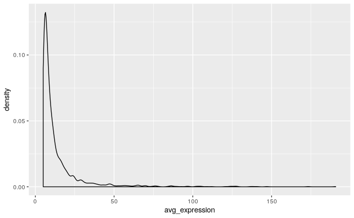

```r
ggplot(astrocytoma_normal_df, aes(x = avg_expression)) +
  geom_density()
```

Use the plot you started above and add a `ggtheme` layer to play with its aesthetics (e.g. `theme_classic()`) See the [ggthemes vignette](https://mran.microsoft.com/snapshot/2017-02-04/web/packages/ggthemes/vignettes/ggthemes.html) to see a list of ggtheme options.

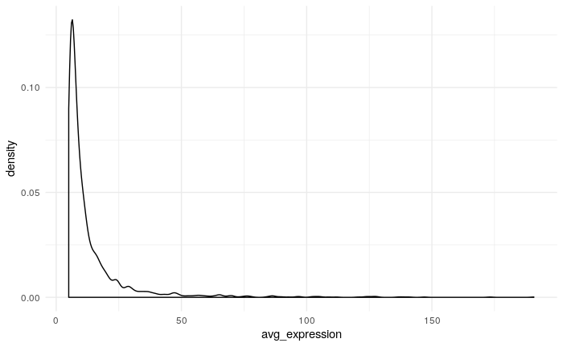

```r
ggplot(astrocytoma_normal_df, aes(x = avg_expression)) +
  geom_density() +
  theme_minimal()
```

Feel free to make other customizations to this plot by adding more layers with `+`. You could add a `ylab()` and `xlab()` and/or by getting inspiration from this [handy cheatsheet for ggplot2](https://rstudio.com/wp-content/uploads/2015/03/ggplot2-cheatsheet.pdf).

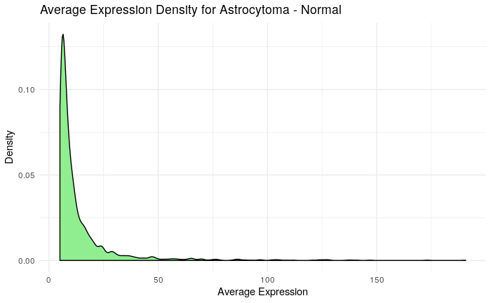

```r
# Customize your plot!
ggplot(astrocytoma_normal_df, aes(x = avg_expression)) +
  geom_density(fill = "lightgreen") +
  theme_minimal() +
  xlab("Average Expression") +
  ylab("Density") +
  ggtitle("Average Expression Density for Astrocytoma - Normal")
```

Save your plot as a `PNG`.

```r
ggsave(
  plot = last_plot(), # This will retrieve the last plot you printed.
  filename = file.path("plots", "average_expression_density_plot.png")
)
```